# `ggplot` lab

```r
theme_set(theme_bw())
majors <- read.csv("https://collinn.github.io/data/majors.csv")
mpg <- as.data.frame(mpg)
mpg$cyl <- factor(mpg$cyl)
mpg$year <- factor(mpg$year)
```

## Grammer of Graphics

```r
head(majors[, c("Per_Male", "Bach_Med_Income", "Category")])
```

```
##   Per_Male Bach_Med_Income Category
## 1     75.1          101600  Science
## 2     81.3           90490  Science
## 3     77.7           94370  Science
## 4     84.5          106600  Science
## 5     88.1           99180  Science
## 6     57.0           76350  Science
```

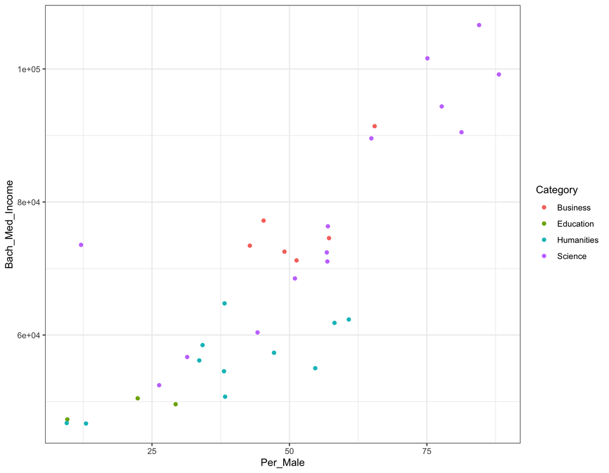

```r
ggplot(majors, aes(x = Per_Male, y = Bach_Med_Income, color = Category)) +
  geom_point()
```

**Question 0**: In a few short sentences, describe what you see here. How are the different variables represented in this plot? Are there any relationships that stand out to you?

## Aesthetics

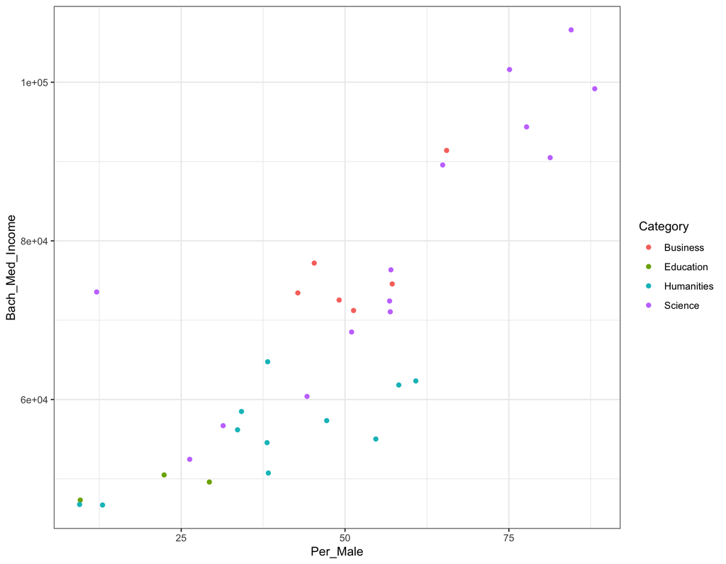

```r
ggplot(majors, aes(Per_Male, Bach_Med_Income, color = Category)) +
  geom_point()
```

**Question 1**: Looking at the multivariate plot above, what additional information is gleaned by including Category as a color as opposed to what we saw when we only had the x- and y-axes? (Similar to Question 0, but here pay attention specifically to the difference between the two.)

For this graph, we can easily analyzing about the relationship between Per_Male and Bach_Med_Income for each category compare to the original one with out the color.

## Problem sets

### Part 1 - Univariate Plots

**Question 2**: The class variable in the mpg dataset details the “type” of car for each observation (pickup, SUV). Create the appropriate graph to demonstrate this distribution of this variable and comment on which class appears to be the most frequent.

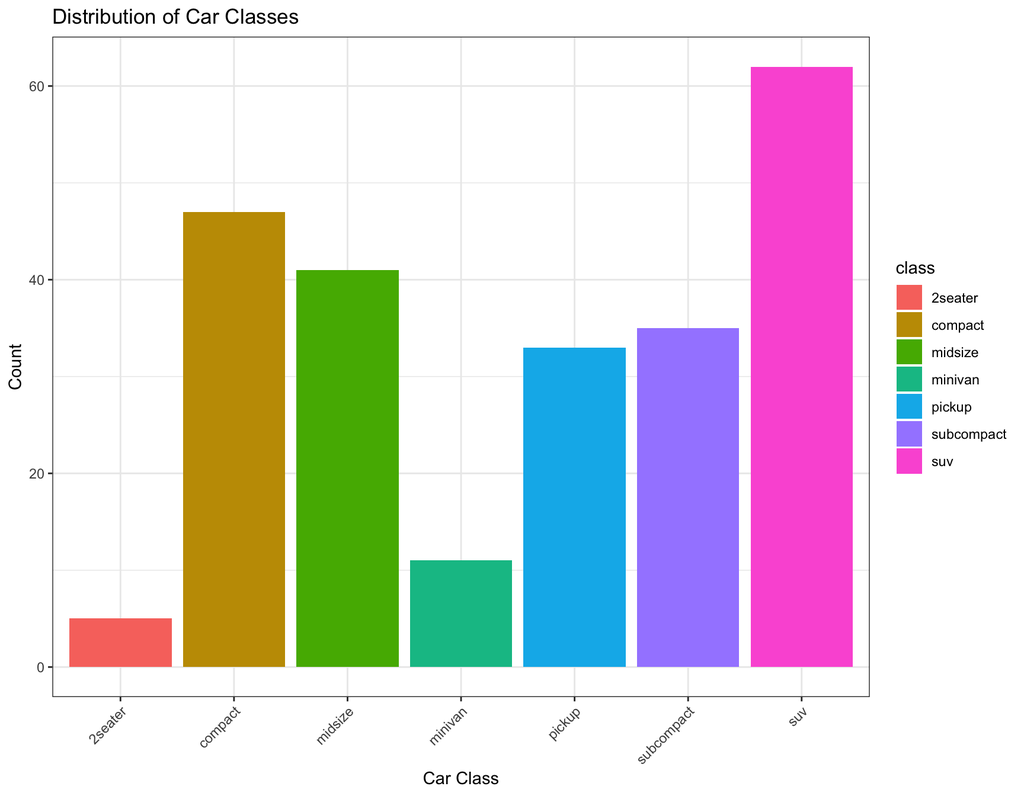

```r
ggplot(mpg, aes(x = class, fill = class)) +
  geom_bar() +
  theme_bw() +
  theme(axis.text.x = element_text(angle = 45, hjust = 1)) +
  labs(title = 'Distribution of Car Classes',
       x = 'Car Class',
       y = 'Count')
```

Based on the graph, the most frequent car class is SUV.

**Question 3**: The cty variable in the mpg dataset details the average fuel economy for the vehicle when driven in the city. Create the appropriate graph to represent this variable. Does this variable appear to be symmetric or skewed?

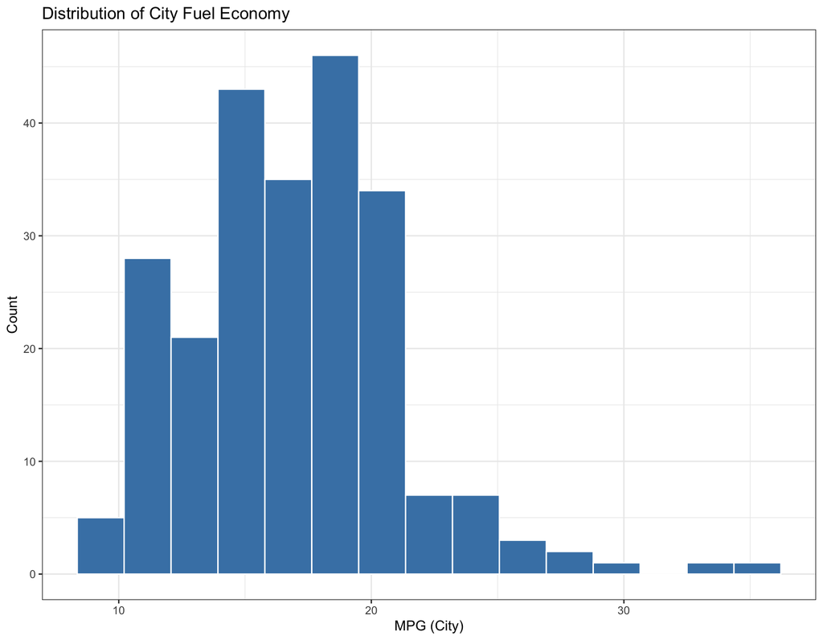

```r
ggplot(mpg, aes(x = cty)) +
  geom_histogram(bins = 15, fill = "steelblue", color = "white") +
  labs(title = "Distribution of City Fuel Economy",
       x = "MPG (City)",
       y = "Count")
```

Based on the histogram, the distribution appears slightly right-skewed with most values between 15-20 MPG.

### Part 2 - Bivariate Plots

```r
kable(head(mpg), caption = "First few rows of the mpg dataset")
```

First few rows of the mpg dataset

| manufacturer | model | displ | year | cyl | trans | drv | cty | hwy | fl | class |
| --- | --- | --- | --- | --- | --- | --- | --- | --- | --- | --- |
| audi | a4 | 1.8 | 1999 | 4 | auto(l5) | f | 18 | 29 | p | compact |
| audi | a4 | 1.8 | 1999 | 4 | manual(m5) | f | 21 | 29 | p | compact |
| audi | a4 | 2.0 | 2008 | 4 | manual(m6) | f | 20 | 31 | p | compact |
| audi | a4 | 2.0 | 2008 | 4 | auto(av) | f | 21 | 30 | p | compact |
| audi | a4 | 2.8 | 1999 | 6 | auto(l5) | f | 16 | 26 | p | compact |
| audi | a4 | 2.8 | 1999 | 6 | manual(m5) | f | 18 | 26 | p | compact |

**Question 4**: Using the mpg dataset, we are interested in determining if either front wheel drive, rear wheel drive, or 4 wheel drive have better highway fuel economy. Create the appropriate plot to show the distribution of fuel economy for each of these types of vehicles. Which appears to have the best fuel economy?

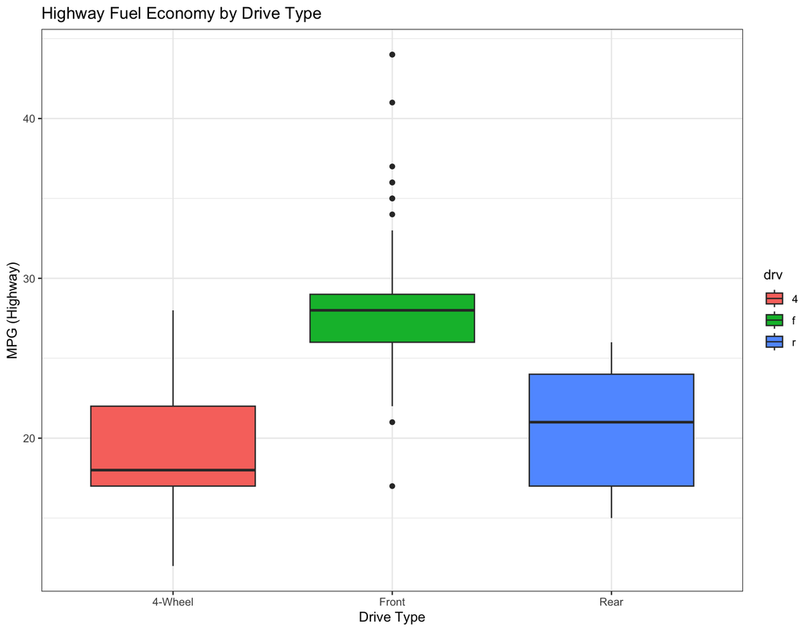

```r
ggplot(mpg, aes(x = drv, y = hwy, fill = drv)) +
  geom_boxplot() +
  labs(title = "Highway Fuel Economy by Drive Type",
       x = "Drive Type",
       y = "MPG (Highway)") +
  scale_x_discrete(labels = c("4" = "4-Wheel", "f" = "Front", "r" = "Rear")) +
  theme_bw()
```

Based on the boxplot, front-wheel drive (f) vehicles have the best highway fuel economy, with the highest median MPG. Four-wheel drive vehicles tend to have lower fuel economy, while rear-wheel drive vehicles fall is in between. Front-wheel drive vehicles also show less variation in their fuel economy compared to the other drive types.

**Question 5**: In the majors dataset, the variable Per_Masters describes the percentage of the workforce within a particular field whose highest degree is a master’s degree. Create a graph to assess whether or not there appears to be a relationship between the percentage of individuals who hold a master’s degree and the percent that is unemployed. What do you find?

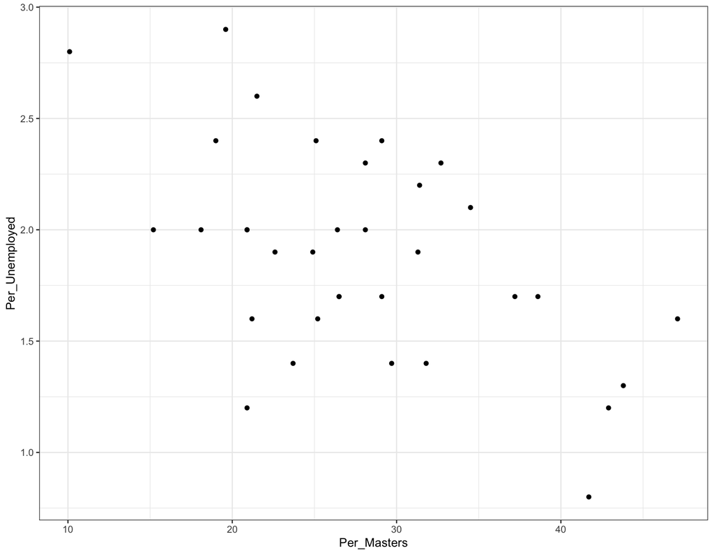

```r
ggplot(majors, aes(x = Per_Masters, y = Per_Unemployed)) +
  geom_point()
```

I find that there is a linear, weak, negative relationship between the percentage of individuals who hold a master’s degree and the percent that is unemployed with a few outliers. It means that in some ways, the master’s degree will somehow prevent unemployment

**Question 6**: Using the mpg dataset, create a plot to find which vehicle class produces the largest number of vehicles with 6 cylinder (cyl) engines. Which produces the largest proportion of 6 cylinder engines?

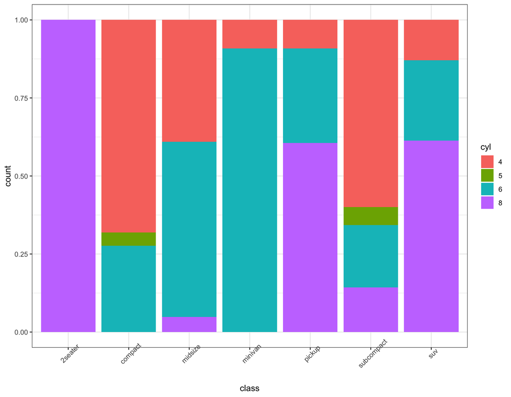

```r
ggplot(mpg, aes(x = class, fill = cyl)) +
  geom_bar(position = "fill") +
theme(axis.text.x = element_text(angle = 45))
```

### Part 3 - Multivariate Plots

**Question 7**: Below is code that reads in tips data that are used in the Example section of this lab. First identify the four variables from the tips data that are used to make this plot and then write code to reproduce it. (This plot uses faceting which has examples at the end of the lab)

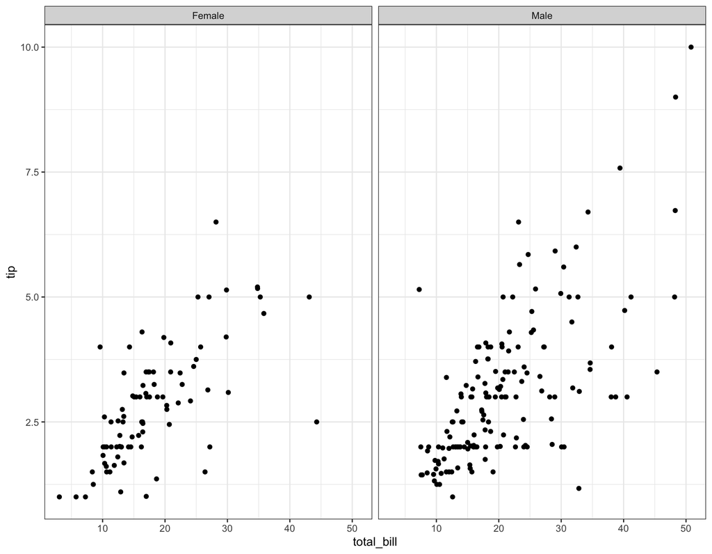

```r
tips <- read.csv("https://collinn.github.io/data/tips.csv")
ggplot(tips, aes(x = total_bill, y = tip)) +
  geom_point() +
  facet_wrap(~sex) +
  labs(x = "total_bill",
       y = "tip") +
  theme_bw()
```

**Question 8**: Using the full version of the college dataset (provided again below), create two different plots box plots with a fill aesthetic to illustrate the relationship between region, type, and admission rate. Which of your plots would be more useful in answering the question, “Do private or public schools generally have a higher admission rate?”

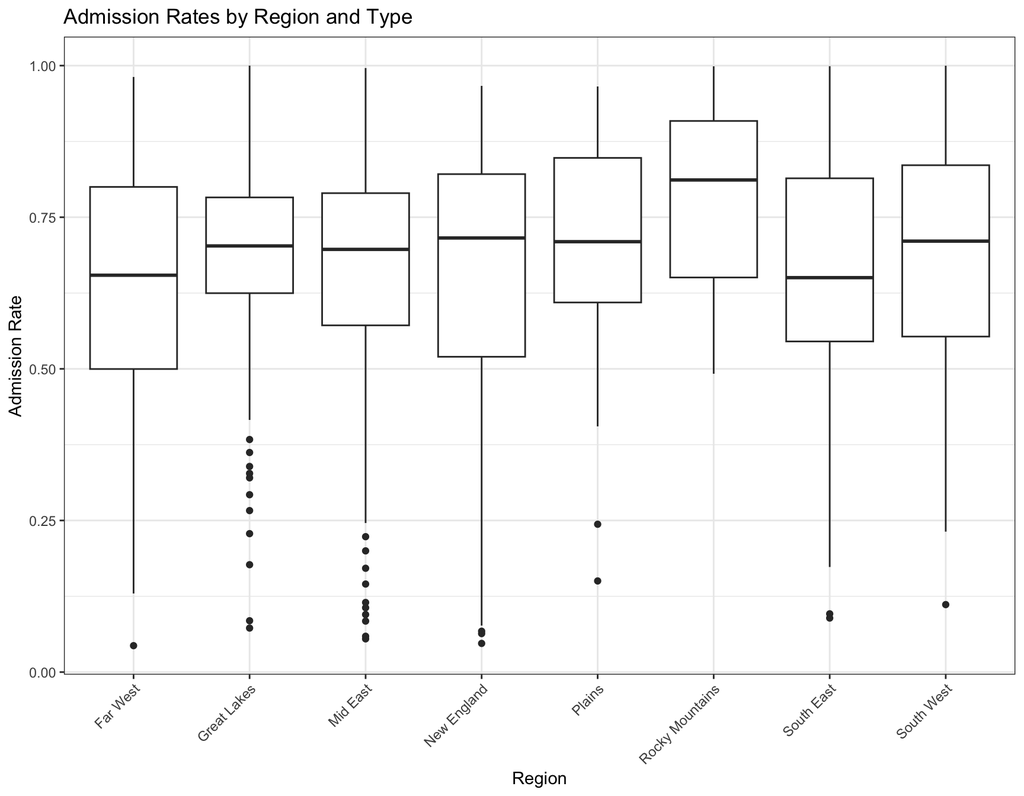

```r
college <- read.csv("https://collinn.github.io/data/college2019.csv")

ggplot(college, aes(x = Region, y = Adm_Rate)) +
  geom_boxplot() +
  labs(title = "Admission Rates by Region and Type",
       x = "Region",
       y = "Admission Rate",
       fill = "School Type") +
  theme_bw() +
  theme(axis.text.x = element_text(angle = 45, hjust = 1))
```

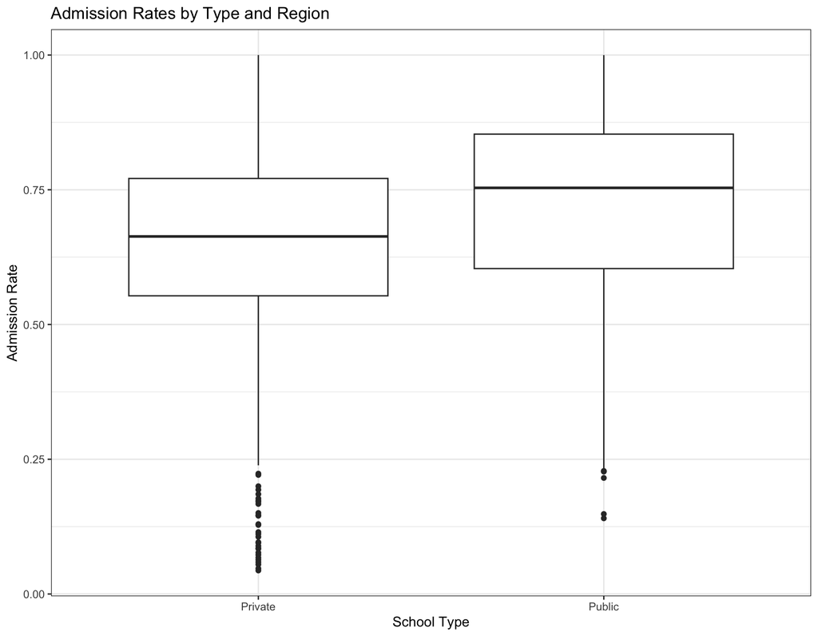

```r
ggplot(college, aes(x = Type, y = Adm_Rate)) +
  geom_boxplot() +
  labs(title = "Admission Rates by Type and Region",
       x = "School Type",
       y = "Admission Rate",
       fill = "Region") +
  theme_bw()
```

The second plot is more useful for answering whether private or public schools have higher admission rates because it directly compares the two types side by side, making it easier to see the overall difference in admission rates between private and public institutions, regardless of region.

**Question 9**: The code below will load a data set containing 970 Hollywood films released between 2007 and 2011, then reduce these data to only include variables that could be known prior to a film’s opening weekend. The data are then simplified further to only include the four largest studios (Warner Bros, Fox, Paramount, and Universal) in the three most common genres (action, comedy, drama). You will use the resulting data for this question.

```r
## Read in data
movies <- read.csv("https://collinn.github.io/data/hollywood.csv")

## Simplify data
movies <- subset(movies, LeadStudio %in% c("Warner Bros", "Fox", "Paramount", "Universal") &
                               Genre %in% c("Action", "Comedy", "Drama"),
                       select = c("Movie", "LeadStudio", "Story", "Genre","Budget",
                                  "TheatersOpenWeek","Year","OpeningWeekend"))
```

Your goal in this question is to create a graphic that effectively differentiates movies with high revenue on opening weekend from those with low revenue on opening weekend (the variable OpeningWeekend records this revenue in millions of US dollars). In other words, using the plotting methods included in this lab, we want to create a visual summary of the data that answers the question: which trends or attributes seem to predict a film having low or high opening weekend revenue.

Your plot should include at least three variables from the dataset, either by including them in the axes, through color or fill, or through faceting. Finally, using the graph you have created, write 2-3 sentences explaining detailing what you have found.

```
## Warning: Removed 3 rows containing missing values or values outside the scale range
## (`geom_point()`).
```

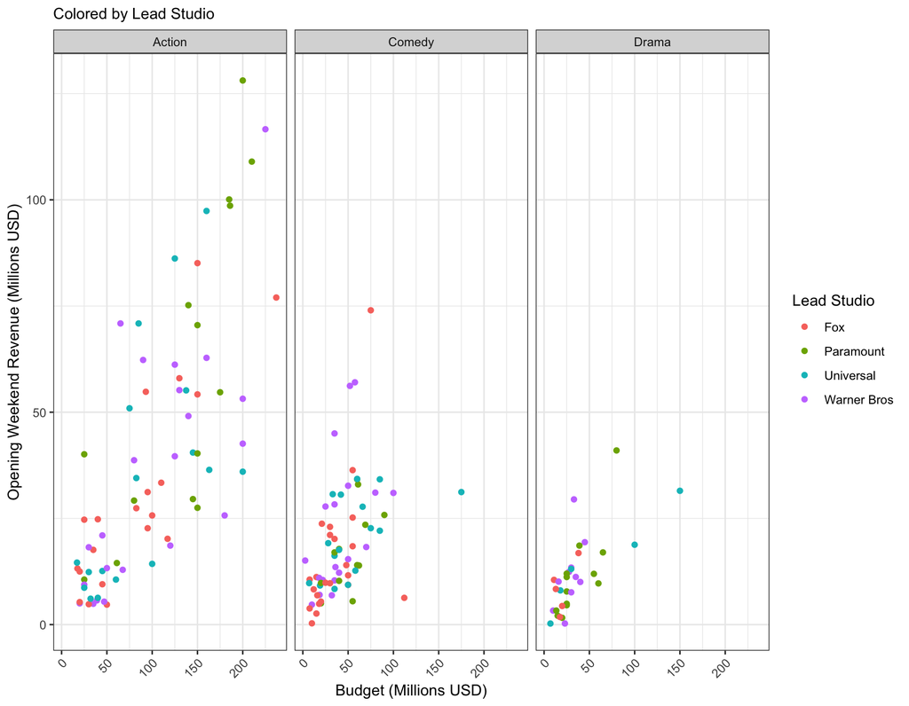

```r
ggplot(movies, aes(x = Budget, y = OpeningWeekend, color = LeadStudio)) +
  geom_point() +
  facet_wrap(~Genre) +
  labs(subtitle = "Colored by Lead Studio",
       x = "Budget (Millions USD)",
       y = "Opening Weekend Revenue (Millions USD)",
       color = "Lead Studio") +
  theme_bw() +
  theme(axis.text.x = element_text(angle = 45, hjust = 1))
```

Action movies show the strongest budget-to-revenue relationship with consistently higher opening revenues for bigger budgets. And comedies and dramas tend to have more moderate returns regardless of budget size. By the studios, Warner Bros and Paramount dominate the high-budget action films.